# R: IPUMS and NHGIS

Jessica Godwin

June 25, 2021

# 1 Setup

# 2 IPUMS and data downloads

**Integrated Public Use Microdata Series (IPUMS)** began decades ago at the Minnesota Population Center where it remains headquartered today. * *Census microdata*, or individual level census information, * Aggregates or 10% or 5 % samples, * Many people have contributed, but Steve Ruggles is main name * See literature uploaded to Literature/IPUMS for development of microdata series * Since expansion of microdata $\rightarrow$ surveys, GIS, DHS

1. Go to [IPUMS-NHGIS](https://www.nhgis.org/)
2. Click “Get Data”.

[figure not shown]

[figure not shown]

[figure not shown]

[figure not shown]

## 2.1 `ipumsr`

- **Upside**
- `ipumsr` is a wonderful package created to make IPUMS data extra usable in `R`
- **Downside**
- format of data is more complicated than others you might have seen
- [`ipumsr` vignette](https://cran.r-project.org/web/packages/ipumsr/vignettes/ipums.html) someone tweeted just this morning that I wish had existed when I had to figure this out for myself years ago
- [`ipumsr` NHGIS vignette](https://cran.r-project.org/web/packages/ipumsr/vignettes/ipums-nhgis.html)
- [MPC IPUMS-NHGIS Exercise 1](https://pop.umn.edu/sites/pop.umn.edu/files/nhgis_training_ex1_2017-01.pdf)

## 2.2 Installation, loading, vignettes

```r
install.packages('ipumsr')
library(ipumsr)
vignette("ipums", package = "ipumsr")
vignette("value-labels", package = "ipumsr")
vignette("ipums-geography", package = "ipumsr")
vignette("ipums-cps", package = "ipumsr")
vignette("ipums-nhgis", package = "ipumsr")
vignette("ipums-terra", package = "ipumsr")
```

# 3 GIS in R: `sf` and `sp`

Note: the vignette entitled `"ipums-geography"` gives a rundown on the packages `sf` (`tidyverse`)and `sp`. I am less familiar with `sf` and the tutorial is `sf` heavy so I will focus on `sp`. You can find info on the `sp` package in the textbook

Bivand, R. S., Pebesma, E. J., & Gomez-Rubio, V. (2008). *Applied spatial data analysis with R*. Springer.

## 3.1 The `SpatialPolygonsDataFrame`

Use `rgdal::readOGR` to load the shapefiles.

The classes of `sp` objects in `R` including `SpatialPolygons` and `SpatialPolygonsDataFrame` are a unique type of object that stores multiple objects within it using **slots**. **Slots** are accessed using the `@` symbol.

Notice below when we look at the individual list items in the `county_2010@polygons` list, they all have a slot that says their `plotOrder` is 1. This is because for each individual polygon, i.e. `county_2010@polygons[[i]]` for `i in 1:nrow(county_2010@data)`, there is only ONE polygon stored in that list of information or if we enter the code `plot(county_2010@polygons[[i]])`, the first (and only) polygon to be drawn will be the $i^{th}$ county according to the ordering of the shapefile.

Other object classes from `sp` include `SpatialPointsDataFrame`, `SpatialPixelsDataFrame`, `SpatialLinesDataFrame`.

```r
county_2010 <- readOGR(dsn = "nhgis0002_shape/nhgis0002_shapefile_tl2010_us_county_2010",
                       layer = "US_county_2010")
## What slots does this object contain?

slotNames(county_2010)
```

```
## [1] "data"        "polygons"    "plotOrder"   "bbox"        "proj4string"
```

```r
## 2D boundaries for shapefile
county_2010@bbox
```

```
##        min     max
## x -7115208 3321632
## y -1685018 4591848
```

```r
## plotting order for polygons
county_2010@plotOrder[1:25]
```

```
##  [1]  623  168 2317  172  626  167  165  622  360 2103  166 2741  961  174  980
## [16]  625 3006 2318 3007  426  237 3073  452  229  463
```

```r
## polygon definitions do not print the
## whole polygons slot ahh!!
## notice below: slots within slots
str(county_2010@polygons[[1]]@Polygons[[1]])
```

```
## Formal class 'Polygon' [package "sp"] with 5 slots
##   ..@ labpt  : num [1:2] -3954679 3286681
##   ..@ area   : num 44368681
##   ..@ hole   : logi FALSE
##   ..@ ringDir: int 1
##   ..@ coords : num [1:431, 1:2] -3955024 -3954555 -3954136 -3953800 -3953441 ...
```

```r
slotNames(county_2010@polygons[[1]])
```

```
## [1] "Polygons"  "plotOrder" "labpt"     "ID"        "area"
```

```r
## usually the centroid
KingCo.idx <- which(county_2010@data$STATEFP10 == 53 &
                      county_2010@data$NAME10 == "King")
county_2010@polygons[[KingCo.idx]]@labpt
```

```
## [1] -1931554  1378613
```

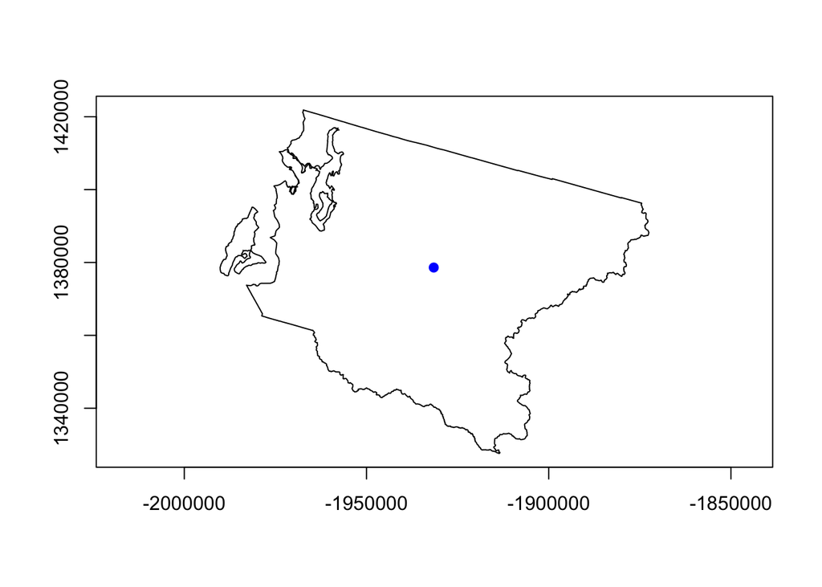

```r
plot(county_2010[KingCo.idx,],axes = TRUE)
points(x = county_2010@polygons[[KingCo.idx]]@labpt[1],
       y = county_2010@polygons[[KingCo.idx]]@labpt[2],
       pch = 19, col = 'blue')
```

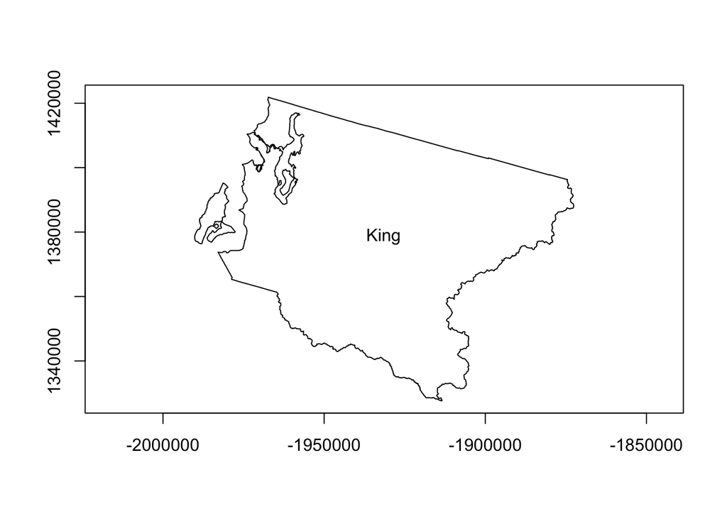

```r
plot(county_2010[KingCo.idx,],axes = TRUE)
text(x = county_2010@polygons[[KingCo.idx]]@labpt[1],
     y = county_2010@polygons[[KingCo.idx]]@labpt[2],
     labels = county_2010@data$NAME10[KingCo.idx])
```

```r
## area of polygon
county_2010@polygons[[1]]@area
```

```
## [1] 18214706340
```

```r
county_2010@polygons[[nrow(county_2010@data)]]@area
```

```
## [1] 1661690225
```

```r
## polygon ID

county_2010@polygons[[1]]@ID
```

```
## [1] "0"
```

```r
county_2010@polygons[[nrow(county_2010@data)]]@ID
```

```
## [1] "3220"
```

It also appears we get a more-meaningful-to-us label for the polygons: the column `county_2010@data$NAME10` contains county names.

```
## [1] 3221   20
```

```
##   STATEFP10 COUNTYFP10 COUNTYNS10 GEOID10         NAME10
## 0        02        013   01419964   02013 Aleutians East
## 1        02        016   01419965   02016 Aleutians West
## 2        28        107   00695776   28107         Panola
## 3        28        101   00695773   28101         Newton
## 4        28        027   00695738   28027        Coahoma
## 5        22        065   00558088   22065        Madison
##                   NAMELSAD10 LSAD10 CLASSFP10 MTFCC10 CSAFP10 CBSAFP10
## 0     Aleutians East Borough     04        H1   G4020    <NA>     <NA>
## 1 Aleutians West Census Area     05        H5   G4020    <NA>     <NA>
## 2              Panola County     06        H1   G4020    <NA>     <NA>
## 3              Newton County     06        H1   G4020    <NA>     <NA>
## 4             Coahoma County     06        H1   G4020    <NA>    17260
## 5             Madison Parish     15        H1   G4020    <NA>    45260
##   METDIVFP10 FUNCSTAT10     ALAND10    AWATER10  INTPTLAT10   INTPTLON10
## 0       <NA>          A 18083148800 20792209033 +55.2437223 -161.9507485
## 1       <NA>          S 11370762625 25190643524 +51.9594469 +178.3388130
## 2       <NA>          A  1774515519    51767046 +34.3652052 -089.9630654
## 3       <NA>          A  1497282694     3879399 +32.4019702 -089.1184115
## 4       <NA>          A  1430818231    79539470 +34.2286699 -090.6031650
## 5       <NA>          A  1617283455    68538668 +32.3658243 -091.2407290
##    GISJOIN  Shape_area Shape_len
## 0 G0200130 18214706340 5139385.9
## 1 G0200160 11406703201 5271825.1
## 2 G2801070  1826282563  174069.5
## 3 G2801010  1501162126  155201.5
## 4 G2800270  1510357780  253786.2
## 5 G2200650  1685822355  307962.0
```

```
##   STATEFP10          COUNTYFP10         COUNTYNS10          GEOID10
##  Length:3221        Length:3221        Length:3221        Length:3221
##  Class :character   Class :character   Class :character   Class :character
##  Mode  :character   Mode  :character   Mode  :character   Mode  :character
##
##
##
##     NAME10           NAMELSAD10           LSAD10           CLASSFP10
##  Length:3221        Length:3221        Length:3221        Length:3221
##  Class :character   Class :character   Class :character   Class :character
##  Mode  :character   Mode  :character   Mode  :character   Mode  :character
##
##
##
##    MTFCC10            CSAFP10            CBSAFP10          METDIVFP10
##  Length:3221        Length:3221        Length:3221        Length:3221
##  Class :character   Class :character   Class :character   Class :character
##  Mode  :character   Mode  :character   Mode  :character   Mode  :character
##
##
##
##   FUNCSTAT10          ALAND10            AWATER10          INTPTLAT10
##  Length:3221        Length:3221        Length:3221        Length:3221
##  Class :character   Class :character   Class :character   Class :character
##  Mode  :character   Mode  :character   Mode  :character   Mode  :character
##
##
##
##   INTPTLON10          GISJOIN            Shape_area          Shape_len
##  Length:3221        Length:3221        Min.   :5.177e+06   Min.   :  10690
##  Class :character   Class :character   1st Qu.:1.105e+09   1st Qu.: 157561
##  Mode  :character   Mode  :character   Median :1.601e+09   Median : 196565
##                                        Mean   :2.894e+09   Mean   : 276471
##                                        3rd Qu.:2.415e+09   3rd Qu.: 264916
##                                        Max.   :3.828e+11   Max.   :7568724
```

```
## [1]  207 2457
```

```
##      STATEFP10 COUNTYFP10 COUNTYNS10 GEOID10 NAME10  NAMELSAD10 LSAD10
## 206         48        269   01383920   48269   King King County     06
## 2456        53        033   01531933   53033   King King County     06
##      CLASSFP10 MTFCC10 CSAFP10 CBSAFP10 METDIVFP10 FUNCSTAT10    ALAND10
## 206         H1   G4020    <NA>     <NA>       <NA>          A 2359146771
## 2456        H1   G4020     500    42660      42644          A 5479291809
##       AWATER10  INTPTLAT10   INTPTLON10  GISJOIN Shape_area Shape_len
## 206    6398129 +33.6141593 -100.2505476 G4802690 2365545006  194544.2
## 2456 495471264 +47.4935537 -121.8323748 G5300330 5580005218  670777.6
```

```
##      STATEFP10 COUNTYFP10 COUNTYNS10 GEOID10  NAME10     NAMELSAD10 LSAD10
## 2088        53        073   01529224   53073 Whatcom Whatcom County     06
##      CLASSFP10 MTFCC10 CSAFP10 CBSAFP10 METDIVFP10 FUNCSTAT10    ALAND10
## 2088        H1   G4020    <NA>    13380       <NA>          A 5456733620
##        AWATER10  INTPTLAT10   INTPTLON10  GISJOIN Shape_area Shape_len
## 2088 1027224451 +48.8426531 -121.8364325 G5300730 5603012436  530791.8
```

```
## [1] 39 20
```

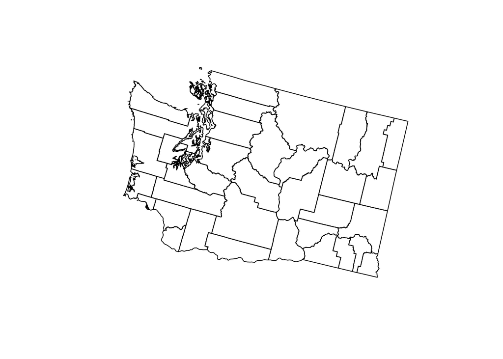

Why is this tilted? The coordinate reference system (CRS) or projection!

```r
proj4string(WA_2010)
```

```
## [1] "+proj=aea +lat_0=37.5 +lon_0=-96 +lat_1=29.5 +lat_2=45.5 +x_0=0 +y_0=0 +datum=NAD83 +units=m +no_defs"
```

```r
?proj4string
```

```
## Help on topic 'proj4string' was found in the following packages:
##
##   Package               Library
##   sp                    /Library/Frameworks/R.framework/Versions/4.0/Resources/library
##   raster                /Library/Frameworks/R.framework/Versions/4.0/Resources/library
##
##
## Using the first match ...
```

```r
WA_2010@proj4string
```

```
## CRS arguments:
##  +proj=aea +lat_0=37.5 +lon_0=-96 +lat_1=29.5 +lat_2=45.5 +x_0=0 +y_0=0
## +datum=NAD83 +units=m +no_defs
```

```r
?spTransform
```

```
## Help on topic 'spTransform' was found in the following packages:
##
##   Package               Library
##   sp                    /Library/Frameworks/R.framework/Versions/4.0/Resources/library
##   rgdal                 /Library/Frameworks/R.framework/Versions/4.0/Resources/library
##
##
## Using the first match ...
```

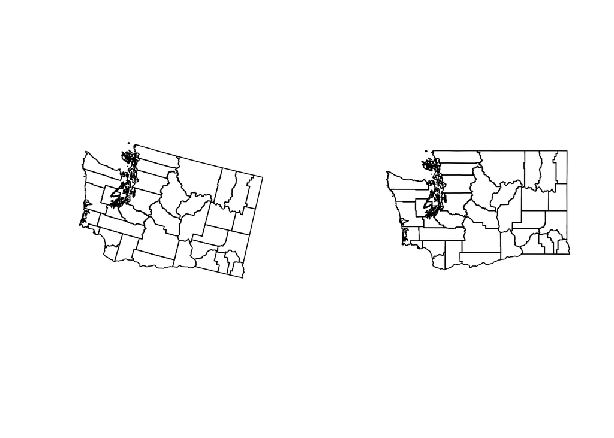

```r
# EPSG <- make_EPSG() # create data frame of available EPSG codes
# EPSG[grepl("WGS 84$", EPSG$note), ]

WA_2010_transform <- spTransform(WA_2010, CRS("+init=epsg:4326"))
par(mfrow=c(1,2))
plot(WA_2010)
plot(WA_2010_transform)
```

```r
rm(WA_2010)
```

# 4 Loading the Extract `data.frame`

```r
WA_data <-  read.csv("nhgis0002_csv/nhgis0002_ts_nominal_county.csv",
                     header = TRUE) %>% dplyr::filter(STATEFP == WA.state.idx)
names(WA_data)
```

```
##  [1] "GISJOIN"  "YEAR"     "STATE"    "STATEFP"  "STATENH"  "COUNTY"
##  [7] "COUNTYFP" "COUNTYNH" "NAME"     "A00AA"    "AV0AA"    "AV1AA"
## [13] "AV1AB"    "B57AA"    "B57AB"    "B57AC"    "B57AD"    "B57AE"
## [19] "B57AF"    "B57AG"    "B57AH"    "B57AI"    "B57AJ"    "B57AK"
## [25] "B57AL"    "B57AM"    "B57AN"    "B57AO"    "B57AP"    "B57AQ"
## [31] "B57AR"    "AR9AA"    "AV0AAM"   "AV1AAM"   "AV1ABM"
```

```r
head(WA_data)
```

```
##    GISJOIN YEAR      STATE STATEFP STATENH          COUNTY COUNTYFP COUNTYNH
## 1 G5300010 1890 Washington      53     530    Adams County        1       10
## 2 G5300030 1890 Washington      53     530   Asotin County        3       30
## 3 G5300055 1890 Washington      53     530 Chehalis County       NA       55
## 4 G5300090 1890 Washington      53     530  Clallam County        9       90
## 5 G5300110 1890 Washington      53     530    Clark County       11      110
## 6 G5300130 1890 Washington      53     530 Columbia County       13      130
##       NAME A00AA AV0AA AV1AA AV1AB B57AA B57AB B57AC B57AD B57AE B57AF B57AG
## 1    Adams  2098    NA    NA    NA    NA    NA    NA    NA    NA    NA    NA
## 2   Asotin  1580    NA    NA    NA    NA    NA    NA    NA    NA    NA    NA
## 3 Chehalis  9249    NA    NA    NA    NA    NA    NA    NA    NA    NA    NA
## 4  Clallam  2771    NA    NA    NA    NA    NA    NA    NA    NA    NA    NA
## 5    Clark 11709    NA    NA    NA    NA    NA    NA    NA    NA    NA    NA
## 6 Columbia  6709    NA    NA    NA    NA    NA    NA    NA    NA    NA    NA
##   B57AH B57AI B57AJ B57AK B57AL B57AM B57AN B57AO B57AP B57AQ B57AR AR9AA
## 1    NA    NA    NA    NA    NA    NA    NA    NA    NA    NA    NA    NA
## 2    NA    NA    NA    NA    NA    NA    NA    NA    NA    NA    NA    NA
## 3    NA    NA    NA    NA    NA    NA    NA    NA    NA    NA    NA    NA
## 4    NA    NA    NA    NA    NA    NA    NA    NA    NA    NA    NA    NA
## 5    NA    NA    NA    NA    NA    NA    NA    NA    NA    NA    NA    NA
## 6    NA    NA    NA    NA    NA    NA    NA    NA    NA    NA    NA    NA
##   AV0AAM AV1AAM AV1ABM
## 1     NA     NA     NA
## 2     NA     NA     NA
## 3     NA     NA     NA
## 4     NA     NA     NA
## 5     NA     NA     NA
## 6     NA     NA     NA
```

```r
summary(WA_data)
```

```
##    GISJOIN              YEAR              STATE              STATEFP
##  Length:537         Length:537         Length:537         Min.   :53
##  Class :character   Class :character   Class :character   1st Qu.:53
##  Mode  :character   Mode  :character   Mode  :character   Median :53
##                                                           Mean   :53
##                                                           3rd Qu.:53
##                                                           Max.   :53
##
##     STATENH       COUNTY             COUNTYFP        COUNTYNH
##  Min.   :530   Length:537         Min.   : 1.00   Min.   : 10.0
##  1st Qu.:530   Class :character   1st Qu.:19.00   1st Qu.:190.0
##  Median :530   Mode  :character   Median :39.00   Median :390.0
##  Mean   :530                      Mean   :39.28   Mean   :390.9
##  3rd Qu.:530                      3rd Qu.:59.00   3rd Qu.:590.0
##  Max.   :530                      Max.   :77.00   Max.   :770.0
##                                   NA's   :3
##      NAME               A00AA             AV0AA             AV1AA
##  Length:537         Min.   :    486   Min.   :   2246   Min.   :  1092
##  Class :character   1st Qu.:   7924   1st Qu.:  16659   1st Qu.:  8362
##  Mode  :character   Median :  20458   Median :  43790   Median : 21968
##                     Mean   :  74146   Mean   : 135750   Mean   : 67538
##                     3rd Qu.:  55431   3rd Qu.: 102837   3rd Qu.: 51857
##                     Max.   :1931249   Max.   :1940777   Max.   :967800
##                     NA's   :39        NA's   :303       NA's   :303
##      AV1AB            B57AA            B57AB            B57AC
##  Min.   :  1146   Min.   :    96   Min.   :   107   Min.   :   159
##  1st Qu.:  8294   1st Qu.:  1100   1st Qu.:  1211   1st Qu.:  1332
##  Median : 21726   Median :  2862   Median :  3181   Median :  3405
##  Mean   : 68212   Mean   :  9166   Mean   :  9494   Mean   :  9649
##  3rd Qu.: 51965   3rd Qu.:  7674   3rd Qu.:  7580   3rd Qu.:  7942
##  Max.   :972977   Max.   :120294   Max.   :113295   Max.   :114122
##  NA's   :303      NA's   :342      NA's   :342      NA's   :342
##      B57AD             B57AE           B57AF             B57AG
##  Min.   :   92.0   Min.   :   18   Min.   :    4.0   Min.   :   13
##  1st Qu.:  830.5   1st Qu.:  396   1st Qu.:  156.5   1st Qu.:  148
##  Median : 2066.0   Median : 1588   Median :  719.0   Median :  641
##  Mean   : 5823.1   Mean   : 3981   Mean   : 2022.7   Mean   : 1954
##  3rd Qu.: 4876.5   3rd Qu.: 3795   3rd Qu.: 1899.0   3rd Qu.: 1786
##  Max.   :69124.0   Max.   :48390   Max.   :24431.0   Max.   :24434
##  NA's   :342       NA's   :342     NA's   :342       NA's   :342
```

[output cut: 17 more lines]

```
##  Min.   :   190   Min.   :   95   Min.   :   18.0   Min.   :23.60
##  1st Qu.:  1341   1st Qu.:  669   1st Qu.:  197.5   1st Qu.:31.27
##  Median :  3101   Median : 1696   Median :  522.0   Median :35.00
##  Mean   :  8129   Mean   : 4650   Mean   : 1676.2   Mean   :35.90
##  3rd Qu.:  7134   3rd Qu.: 4026   3rd Qu.: 1477.0   3rd Qu.:39.33
##  Max.   :112747   Max.   :68348   Max.   :33784.0   Max.   :53.90
##  NA's   :342      NA's   :342     NA's   :342       NA's   :381
##      AV0AAM        AV1AAM           AV1ABM
##  Min.   :0     Min.   :  0.00   Min.   :  0.00
##  1st Qu.:0     1st Qu.: 65.50   1st Qu.: 65.50
##  Median :0     Median : 98.00   Median : 98.00
##  Mean   :0     Mean   : 95.85   Mean   : 95.85
##  3rd Qu.:0     3rd Qu.:134.00   3rd Qu.:134.00
##  Max.   :0     Max.   :182.00   Max.   :182.00
##  NA's   :498   NA's   :498      NA's   :498
```

Our shapefile has 39 polygons, they are indexed according to the row names of the `WA_2010_transform@data` `data.frame`. Let’s load the data now. Our data have 537= (11 time points x 39 counties) + 34, 36, 38 for years 1890, 1900, 1910. Since we want to plot $Y_i$ and not $Y_{ij}$ we need to collapse our data over subgroups within counties.

# 5 Aggregating and cleaning data

```r
# in tidyverse, easiest way is
# group_by() + summarise()
WA_2010_tidy <- WA_data %>% group_by(STATEFP, COUNTYFP, YEAR) %>%
  summarise(Total = sum(A00AA, na.rm = TRUE),
            Male = sum(AV1AA, na.rm = TRUE),
            Female = sum(AV1AB, na.rm = TRUE)) %>%
  filter(YEAR == 2010)
## Did you know?
## data.frames are lists?
class(WA_2010_tidy)
```

```
## [1] "grouped_df" "tbl_df"     "tbl"        "data.frame"
```

```r
str(WA_2010_tidy)
```

```
## grouped_df [39 × 6] (S3: grouped_df/tbl_df/tbl/data.frame)
##  $ STATEFP : int [1:39] 53 53 53 53 53 53 53 53 53 53 ...
##  $ COUNTYFP: int [1:39] 1 3 5 7 9 11 13 15 17 19 ...
##  $ YEAR    : chr [1:39] "2010" "2010" "2010" "2010" ...
##  $ Total   : int [1:39] 18728 21623 175177 72453 71404 425363 4078 102410 38431 7551 ...
##  $ Male    : int [1:39] 9544 10453 87486 36130 35429 209954 2022 50542 19198 3905 ...
##  $ Female  : int [1:39] 9184 11170 87691 36323 35975 215409 2056 51868 19233 3646 ...
##  - attr(*, "groups")= tibble [39 × 3] (S3: tbl_df/tbl/data.frame)
##   ..$ STATEFP : int [1:39] 53 53 53 53 53 53 53 53 53 53 ...
##   ..$ COUNTYFP: int [1:39] 1 3 5 7 9 11 13 15 17 19 ...
##   ..$ .rows   : list<int> [1:39]
##   .. ..$ : int 1
##   .. ..$ : int 2
##   .. ..$ : int 3
##   .. ..$ : int 4
##   .. ..$ : int 5
##   .. ..$ : int 6
##   .. ..$ : int 7
##   .. ..$ : int 8
##   .. ..$ : int 9
##   .. ..$ : int 10
##   .. ..$ : int 11
##   .. ..$ : int 12
##   .. ..$ : int 13
##   .. ..$ : int 14
##   .. ..$ : int 15
##   .. ..$ : int 16
##   .. ..$ : int 17
##   .. ..$ : int 18
##   .. ..$ : int 19
##   .. ..$ : int 20
##   .. ..$ : int 21
##   .. ..$ : int 22
##   .. ..$ : int 23
##   .. ..$ : int 24
##   .. ..$ : int 25
##   .. ..$ : int 26
##   .. ..$ : int 27
##   .. ..$ : int 28
##   .. ..$ : int 29
##   .. ..$ : int 30
##   .. ..$ : int 31
##   .. ..$ : int 32
##   .. ..$ : int 33
##   .. ..$ : int 34
##   .. ..$ : int 35
##   .. ..$ : int 36
##   .. ..$ : int 37
##   .. ..$ : int 38
##   .. ..$ : int 39
##   .. ..@ ptype: int(0)
##   ..- attr(*, ".drop")= logi TRUE
```

```r
is.data.frame(WA_2010_tidy)
```

```
## [1] TRUE
```

```r
is.list(WA_2010_tidy)
```

```
## [1] TRUE
```

```r
lapply(WA_2010_tidy, function(x){sum(is.na(x))})
```

```
## $STATEFP
## [1] 0
##
## $COUNTYFP
## [1] 0
##
## $YEAR
## [1] 0
##
## $Total
## [1] 0
##
## $Male
## [1] 0
##
## $Female
## [1] 0
```

```r
?aggregate
```

```
## Help on topic 'aggregate' was found in the following packages:
##
##   Package               Library
##   sf                    /Library/Frameworks/R.framework/Versions/4.0/Resources/library
##   sp                    /Library/Frameworks/R.framework/Versions/4.0/Resources/library
##   raster                /Library/Frameworks/R.framework/Versions/4.0/Resources/library
##   stats                 /Library/Frameworks/R.framework/Versions/4.0/Resources/library
##
##
## Using the first match ...
```

```r
WA_sum <- aggregate(cbind(A00AA, AV1AA, AV1AB) ~ STATEFP + COUNTYFP + YEAR,
                    data = WA_data,
                    FUN = sum)

head(WA_sum)
```

```
##   STATEFP COUNTYFP YEAR  A00AA AV1AA AV1AB
## 1      53        1 1970  12014  6049  5965
## 2      53        3 1970  13799  6650  7149
## 3      53        5 1970  67540 33358 34182
## 4      53        7 1970  41355 20204 21151
## 5      53        9 1970  34770 17412 17358
## 6      53       11 1970 128454 62968 65486
```

```r
WA_2010_base <- WA_sum[WA_sum$YEAR == 2010, ]
names(WA_2010_base)[-c(1:3)] <- c("Total",
                                  "Male", "Female")

head(WA_2010_base)
```

```
##     STATEFP COUNTYFP YEAR  Total   Male Female
## 157      53        1 2010  18728   9544   9184
## 158      53        3 2010  21623  10453  11170
## 159      53        5 2010 175177  87486  87691
## 160      53        7 2010  72453  36130  36323
## 161      53        9 2010  71404  35429  35975
## 162      53       11 2010 425363 209954 215409
```

```r
head(WA_2010_tidy)
```

```
## # A tibble: 6 x 6
## # Groups:   STATEFP, COUNTYFP [6]
##   STATEFP COUNTYFP YEAR   Total   Male Female
##     <int>    <int> <chr>  <int>  <int>  <int>
## 1      53        1 2010   18728   9544   9184
## 2      53        3 2010   21623  10453  11170
## 3      53        5 2010  175177  87486  87691
## 4      53        7 2010   72453  36130  36323
## 5      53        9 2010   71404  35429  35975
## 6      53       11 2010  425363 209954 215409
```

```r
WA_2010_base$COUNTYFP
```

```
##  [1]  1  3  5  7  9 11 13 15 17 19 21 23 25 27 29 31 33 35 37 39 41 43 45 47 49
## [26] 51 53 55 57 59 61 63 65 67 69 71 73 75 77
```

```r
WA_2010_tidy$COUNTYFP
```

```
##  [1]  1  3  5  7  9 11 13 15 17 19 21 23 25 27 29 31 33 35 37 39 41 43 45 47 49
## [26] 51 53 55 57 59 61 63 65 67 69 71 73 75 77
```

```r
WA_2010_transform@data$COUNTYFP10
```

```
##  [1] "077" "007" "035" "043" "045" "051" "057" "009" "019" "003" "021" "011"
## [13] "037" "039" "015" "049" "067" "041" "017" "073" "031" "005" "075" "065"
## [25] "033" "071" "023" "001" "055" "061" "059" "025" "029" "027" "053" "069"
## [37] "013" "063" "047"
```

# 6 Merging data

We need to fix up the COUNTYFP columns so that they match those in the shapefiles.

```r
doub.digit.idx <- which(nchar(WA_2010_base$COUNTYFP) == 2)
WA_2010_base$COUNTYFP[doub.digit.idx] <- paste0("0",
                                                WA_2010_base$COUNTYFP[doub.digit.idx])
WA_2010_base$COUNTYFP[-doub.digit.idx] <- paste0("00",
                                                 WA_2010_base$COUNTYFP[-doub.digit.idx])

WA_2010_tidy <- WA_2010_tidy %>%
  mutate(COUNTYFP = ifelse(nchar(COUNTYFP) == 2,
                           paste0("0",COUNTYFP),
                           paste0("00", COUNTYFP)))
head(WA_2010_base)
```

```
##     STATEFP COUNTYFP YEAR  Total   Male Female
## 157      53      001 2010  18728   9544   9184
## 158      53      003 2010  21623  10453  11170
## 159      53      005 2010 175177  87486  87691
## 160      53      007 2010  72453  36130  36323
## 161      53      009 2010  71404  35429  35975
## 162      53      011 2010 425363 209954 215409
```

```r
head(WA_2010_tidy)
```

```
## # A tibble: 6 x 6
## # Groups:   STATEFP, COUNTYFP [6]
##   STATEFP COUNTYFP YEAR   Total   Male Female
##     <int> <chr>    <chr>  <int>  <int>  <int>
## 1      53 001      2010   18728   9544   9184
## 2      53 003      2010   21623  10453  11170
## 3      53 005      2010  175177  87486  87691
## 4      53 007      2010   72453  36130  36323
## 5      53 009      2010   71404  35429  35975
## 6      53 011      2010  425363 209954 215409
```

Also, to be in good practice, let’s add some info from the shapefile to our data for our own benefit. First I’ll show two ways to do this in base `R` using `merge()` or `match()`. Then `tidyverse` versions.

Note the `sort = FALSE` argument in `merge()` allows the output to be returned according to the ordering of the merging variable in the `x` argument data frame, i.e. by `WA_2010_transform@data$COUNTYFP10` instead of by `WA_2010_base$COUNTYFP`.

## 6.1 base `R`

```r
# several ways to go about this, but in the end i want my data frame to
# be in the same FIPS ordering as the shapefile

# using merge()
tmp1 <- merge(x = WA_2010_transform@data[, c("COUNTYFP10","NAME10")],
              y = WA_2010_base,
              by.x = 'COUNTYFP10',
              by.y = 'COUNTYFP',
              sort = FALSE)
head(tmp1)
```

```
##   COUNTYFP10       NAME10 STATEFP YEAR  Total   Male Female
## 1        077       Yakima      53 2010 243231 121676 121555
## 2        007       Chelan      53 2010  72453  36130  36323
## 3        035       Kitsap      53 2010 251133 127155 123978
## 4        043      Lincoln      53 2010  10570   5277   5293
## 5        045        Mason      53 2010  60699  31400  29299
## 6        051 Pend Oreille      53 2010  13001   6593   6408
```

```r
# using match()
tmp2 <- WA_2010_base[match(WA_2010_transform@data$COUNTYFP10,
                           WA_2010_base$COUNTYFP),]
head(tmp2)
```

```
##     STATEFP COUNTYFP YEAR  Total   Male Female
## 195      53      077 2010 243231 121676 121555
## 160      53      007 2010  72453  36130  36323
## 174      53      035 2010 251133 127155 123978
## 178      53      043 2010  10570   5277   5293
## 179      53      045 2010  60699  31400  29299
## 182      53      051 2010  13001   6593   6408
```

```r
tmp2$CountyName <- WA_2010_transform@data$NAME10[match(tmp2$COUNTYFP,
                                                       WA_2010_transform@data$COUNTYFP10)]

head(tmp2)
```

```
##     STATEFP COUNTYFP YEAR  Total   Male Female   CountyName
## 195      53      077 2010 243231 121676 121555       Yakima
## 160      53      007 2010  72453  36130  36323       Chelan
## 174      53      035 2010 251133 127155 123978       Kitsap
## 178      53      043 2010  10570   5277   5293      Lincoln
## 179      53      045 2010  60699  31400  29299        Mason
## 182      53      051 2010  13001   6593   6408 Pend Oreille
```

```r
WA_2010_base <- tmp2

rm(tmp1, tmp2)
```

## 6.2 using `tidyverse`

```r
?right_join
?left_join
tmp1 <- WA_2010_transform@data %>%
  select(COUNTYFP10, NAME10) %>%
  left_join(WA_2010_tidy,
            by = c("COUNTYFP10" = "COUNTYFP"),
            keep = FALSE)
head(tmp1)
```

```
##   COUNTYFP10       NAME10 STATEFP YEAR  Total   Male Female
## 1        077       Yakima      53 2010 243231 121676 121555
## 2        007       Chelan      53 2010  72453  36130  36323
## 3        035       Kitsap      53 2010 251133 127155 123978
## 4        043      Lincoln      53 2010  10570   5277   5293
## 5        045        Mason      53 2010  60699  31400  29299
## 6        051 Pend Oreille      53 2010  13001   6593   6408
```

```r
WA_2010_tidy <- tmp1
rm(tmp1)

head(WA_2010_base$COUNTYFP)
```

```
## [1] "077" "007" "035" "043" "045" "051"
```

```r
head(WA_2010_tidy$COUNTYFP)
```

```
## [1] "077" "007" "035" "043" "045" "051"
```